# Who’s with Who? Bayesian Analysis of Heteroscedastic Sex Partner Choice Data

Caleb Easterly

# What are the chances? Of getting an STI, that is.

Mathematical models of disease are important tools for guiding health policy, such as human papillomavirus (HPV) vaccination. In mathematical modeling of sexually transmitted infections, it is important to know a person’s risk of infection. Clearly, a person’s risk should depend on the number of sex partners they have, and should also depend on the prevalence (percent of people infected) in the population of their partners. Sexually activity varies with age, so we can include age as a variable in a mathematical model. In the end, we need three pieces to estimate person X’s annual risk (in this simplified model)(Garnett 2002):

- the age distribution of X’s partners
- the annual rate at which X acquires partners
- the prevalence of the infection by age

This post focuses on the first point: the age distribution of someone’s partners. Luckily, we have data to estimate this! There has been a series of very detailed surveys in England called the National Survey on Sexual Attitudes and Lifestyles (Johnson 2015). We will use the 3rd survey, with data collected between 2010 and 2012.

```r
names(spc_df)
```

```
## [1] "sex_dummy" "ptage"     "chsage"    "sex"
```

```r
summary(spc_df)
```

```
##    sex_dummy          ptage           chsage          sex
##  Min.   :0.0000   Min.   :13.00   Min.   :12.00   Length:18233
##  1st Qu.:0.0000   1st Qu.:19.00   1st Qu.:19.00   Class :character
##  Median :1.0000   Median :23.00   Median :23.00   Mode  :character
##  Mean   :0.5368   Mean   :26.02   Mean   :26.21
##  3rd Qu.:1.0000   3rd Qu.:30.00   3rd Qu.:30.00
##  Max.   :1.0000   Max.   :83.00   Max.   :73.00
```

```r
nrow(spc_df)
```

```
## [1] 18233
```

The variables are as follows:

- `sex_dummy`: Dummy variable with 0 indicating male and 1 indicating female
- `ptage`: the age of the partner at the initiation of reported sexual partnership
- `chsage`: the age of the survey respondent (“chooser”) at the initiation of a reported sexual partnership

The goal is to model the distribution of `ptage` as a function of `chsage` and `sex_dummy`. We are concerned with 12 to 74 year-olds in the model, so we define a vector with those ages:

```r
ages <- 12:74
n_age <- length(ages)
```

Bayesian methods are intimately tied to probability distributions, and for that reason they make an attractive analysis method. The overall method to estimate the probability distribution for partner age for some chooser age $x$ is, in the context of our study:

1. draw $\beta_0, \beta_1$, etc. from their distributions
2. draw a partner age from the distribution $N(\beta_0 + \beta_1 x, \ \tau^{-1})$ (for the normal, homoscedastic model).

By doing this many times, we can get a partner age distribution for each age $x$ in a satisfing probabilitistic manner. In contrast, the frequentist method previously used in (Easterly 2017) to defines a distribution using the estimated mean and variance.

We want to develop the best model for the age distributions, which we define as the model that best explains the data. To do this, we develop four different linear models which contain different variance structures. As we discuss next, the data show different variance across ages (heteroscedasticity), so we compare parametric models for the heteroscedastic variance and use a homoscedastic model as a baseline comparison.

First, we discuss the identification of heteroscedasticity. Then we specify the four models that we are comparing and introduce the *deviance information criterion* (DIC), the measure we use to compare the models. Finally, we compare the DICs and identify some interesting parameter values in the models, such as the effect of gender on a partner’s age.

# Why Account for Heteroscedasticity?

While exploring the data, it appeared that there was more variance at older ages (See Figure 1 below).

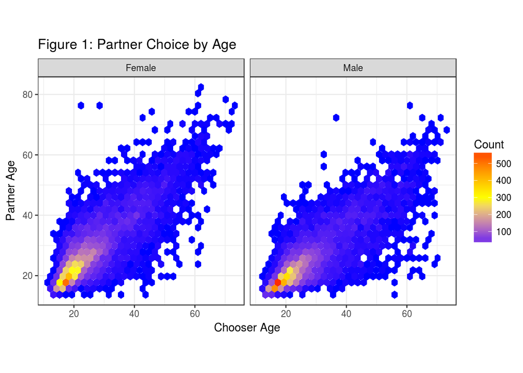

```r
ggplot(spc_df) +
    geom_hex(aes(x = chsage, y = ptage)) +
    coord_fixed() +
    labs(x = "Chooser Age", y = "Partner Age",
         title = "Figure 1: Partner Choice by Age") +
    scale_fill_gradient2(name = "Count", low = "blue", high = "red",
                         mid = "yellow",
                          midpoint = 300) +
    facet_grid(.~sex) +
    theme_bw()
```

We can also visualize the sample variance at each chooser age:

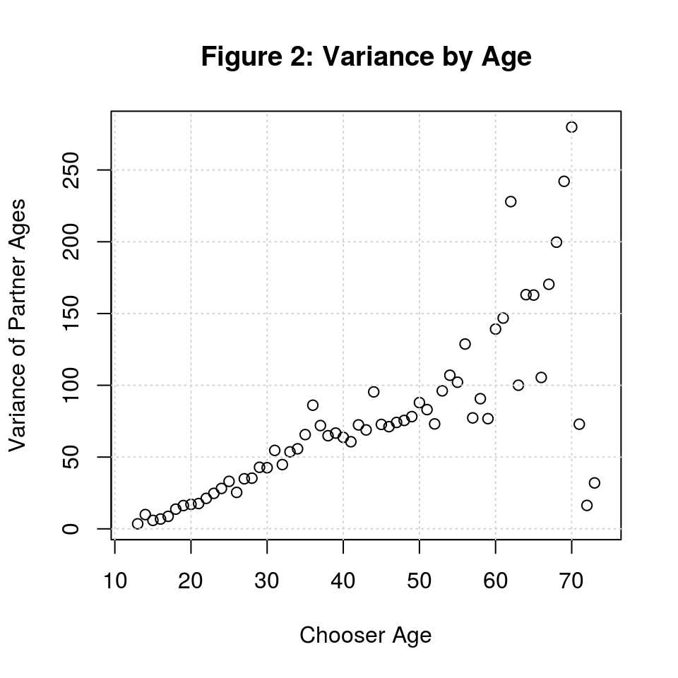

```r
vars <- rep(0, n_age)
for (i in 1:n_age){
  chooser_current <- subset(spc_df, chsage == ages[i])
  vars[i] <- sd(chooser_current$ptage)^2
}

plot(x = ages, y = vars,
     xlab = "Chooser Age",
     ylab = "Variance of Partner Ages",
     main = "Figure 2: Variance by Age")
grid()
```

From Figure 1, we see that there are many fewer new partnerships reported at older ages, and the few that are reported are spread more widely than those at younger ages. We use a statistical test, the Breusch-Pagan test, to examine more rigorously the possible heteroscedasticity.

Heteroscedasticity matters because if there is, in fact, larger variance at older ages, this will have a strong effect on the partner choice distributions. As we want to estimate the distributions as accurately as possible, it is important to consider that some chooser ages may have a wider range of partner ages than other chooser ages.

## The Breusch-Pagan Test

The Breusch-Pagan (BP) test amounts to modeling the residuals of a given model as a linear function of the explanatory variables (Breusch and Pagan 1979):

$$r_i = a_0 + a_1 X_i$$

Then, we use the statistic $n \cdot R^2 \sim \chi^2_{p-1}$, where $n$ is the number of observations and $R^2$ has the usual meaning. Under the null hypothesis $a_1 = 0$ the statistic is distributed as $\chi^2$ with $p - 1$ degrees of freedom - in our case, it is $\chi^2_1$. If the probability of observing this statistic is small (traditionally, less than $0.05$), we can reject the null hypothesis that the data are homoscedastic.

Another useful resource for heteroscedasticity and the BP test is [here](http://www.ncku.edu.tw/~account/chinese/course/eco91/lecture9.pdf), and for the $\chi^2$ distribution a useful resource is [here](http://onlinestatbook.com/2/chi_square/distribution.html).

In R, the BP test can be carried out with the package `lmtest`, which has a function `bptest()`.

```r
require(lmtest)
bp_test_lm <- lm(ptage ~ chsage,
               data = spc_df)

bptest(bp_test_lm)
```

```
##
##  studentized Breusch-Pagan test
##
## data:  bp_test_lm
## BP = 1930, df = 1, p-value < 2.2e-16
```

As we see, the $p$-value is vanishingly small, so we can reject the hypothesis that the data are homoscedastic with respect to age. We also consider if the data are homoscedastic with respect to sex:

```r
bp_test_lm_sex_only <- lm(ptage ~ sex_dummy,
                          data = spc_df)
bptest(bp_test_lm_sex_only)
```

```
##
##  studentized Breusch-Pagan test
##
## data:  bp_test_lm_sex_only
## BP = 15.066, df = 1, p-value = 0.0001038
```

We can also reject the null hypothesis that the data are homoscedastic with respect to sex! For that reason, we use both methods to explain the variance in the analyses that follow.

Next, we describe the 4 models under comparison.

# Models

For all analyses, we use the following definitions: let $Y_i$ be the $i$th partner age, $X_i$ be the $i$th chooser age, and $G_i$ be the indicator of whether the chooser is male ($G_1 = 0$) or female ($G_i = 1$).

In general, we make age predictions using the function `het_analysis()`, which calls the C++ function `resid_model_prediction()`, both included in the Code Appendix[^1]. As the posterior is generally intractable, we use simulation to approximate the posterior distributions of the parameters[^2]. The simulation method we use is called Just Another Gibbs Sampler (JAGS). To do the analysis, we use a function called `het_analysis()`, which takes a JAGS model defined as a string in R, compiles the model, samples from it, and uses the samples to make predictions. The definition of `het_analysis()` is in the Code Appendix.

```r
# Number of posterior samples
nreps <- 50000
```

This is the function we use to plot the results:

```r
plot_preds <- function(preds, title){
  ggplot(preds$predictions) +
    geom_bin2d(aes(x = age, y=pred)) +
    facet_grid(.~sex) +
    coord_fixed() +
    scale_fill_gradient(name = "Count", low = "blue",
                         high = "red") +
    theme_bw() +
    ggtitle(title)
}
```

## Constant Vigilance! Uhh…constant variance!

First, the homoscedastic model. In all the models, the precision (reciprocal of the variance) was arbitrarily chosen to be small so that the priors were vague.

```r
AgeModelHomNorm <- "model{
  #Data
  for (i in 1:length(y)) {
    y[i] ~ dnorm(beta0 + beta1*x[i] + beta2*sex[i], tau)
  }
  #Priors
  beta0 ~ dnorm(0, 1/1000)
  beta1 ~ dnorm(1, 1/1000)
  beta2 ~ dnorm(0, 1/1000)
  tau ~ dgamma(1/10000, 1/10000)
}"

norm_hom_preds <- het_analysis(nreps, AgeModelHomNorm,
                         distribution = "norm",
                         variance_model = "hom",
                         spc_df, jags.plot = FALSE)
```

Plot the results:

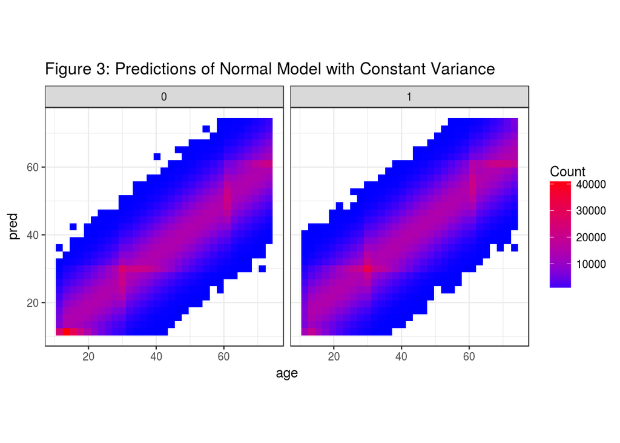

```r
plot_preds(norm_hom_preds, "Figure 3: Predictions of Normal Model with Constant Variance")
```

## Linear Variance

where $\hat{\sigma}^2$ was the average variance for a given chooser age. We calculate that using the following code:

```r
chs_var <- rep(0, n_age)
for (i in 1:n_age){
  chs_var[i] <- sd(subset(spc_df, chsage == ages[i])$ptage)^2
}
mean_chs_var <- mean(chs_var, na.rm = TRUE)
```

The associated `rjags` code was

```r
AgeModelHetNorm <- paste("model{
  #Data
  for (i in 1:length(y)) {
    y[i] ~ dnorm(beta0 + beta1*x[i] + beta2*sex[i], 1/(alpha0 + alpha1 * x[i] + alpha2 * sex[i]))
  }
  #Priors
  beta0 ~ dnorm(0, 1/1000)
  beta1 ~ dnorm(1, 1/1000)
  beta2 ~ dnorm(0, 1/1000)
  alpha0 ~ dnorm(", mean_chs_var, ", 1/1000)
  alpha1 ~ dnorm(0, 1/1000)
  alpha2 ~ dnorm(0, 1/1000)
  tau ~ dgamma(1/10000, 1/10000)
}")

norm_lin_preds <- het_analysis(nreps, AgeModelHetNorm,
                         distribution = "norm",
                         variance_model = "lin",
                         spc_df, jags.plot = FALSE)
```

Plot the results:

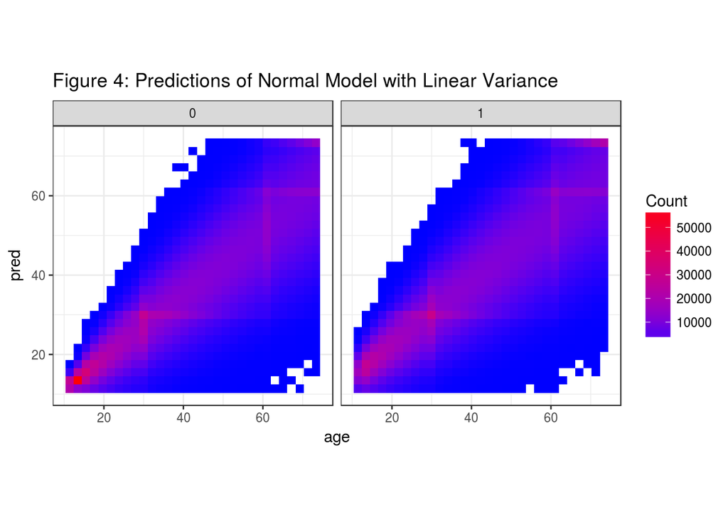

```r
plot_preds(norm_lin_preds, "Figure 4: Predictions of Normal Model with Linear Variance")
```

## Log of Variance

In this model, we assume the log of the variance is a linear function of $X_i$ and $G_i$. That is, we model

$$\begin{split}
Y_i \ | \ \beta_0, \ \beta_1, \beta_2, \alpha_0, \alpha_1, \alpha_2, \ X_i &\sim N(\beta_0 + \beta_1 X_i + \beta_2 G_i, \ \sigma_i^2) \\
\log(\sigma^2_i) &\sim \alpha_0 + \alpha_1 X_i + \alpha_2 G_i
\end{split}$$

```r
AgeModelHetNormLog <- "model{
  #Data
  for (i in 1:length(y)) {
    y[i] ~ dnorm(beta0 + beta1*x[i] + beta2*sex[i], 1/exp(alpha0 + alpha1 * x[i] + alpha2 * sex[i]))
  }
  #Priors
  beta0 ~ dnorm(0, 1/1000)
  beta1 ~ dnorm(1, 1/1000)
  beta2 ~ dnorm(0, 1/1000)
  alpha0 ~ dnorm(65.72845, 1/1000)
  alpha1 ~ dnorm(0, 1/1000)
  alpha2 ~ dnorm(0, 1/1000)
  tau ~ dgamma(1/10000, 1/10000)
}"

norm_log_preds <- het_analysis(nreps, AgeModelHetNormLog,
                         distribution = "norm",
                         variance_model = "loglin",
                         spc_df, jags.plot = FALSE)
```

Plot the results:

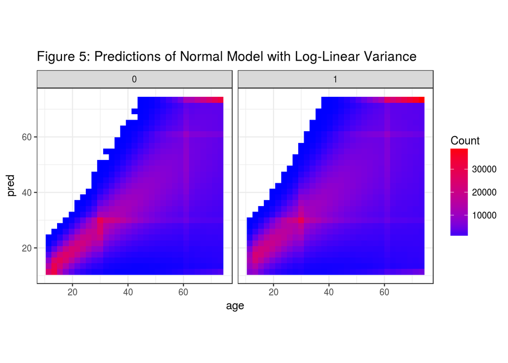

```r
plot_preds(norm_log_preds, "Figure 5: Predictions of Normal Model with Log-Linear Variance")
```

## Square Root of Variance

In this model, we model the square root of the variance (the standard deviation) as a linear function of $X_i$ and $G_i$

$$\begin{split}
Y_i \ | \ \beta_0, \ \beta_1, \beta_2, \alpha_0, \alpha_1, \alpha_2, \ X_i &\sim N(\beta_0 + \beta_1 X_i + \beta_2 G_i, \ \sigma_i^2) \\
\sigma_i &\sim \alpha_0 + \alpha_1 X_i + \alpha_2 G_i
\end{split}$$

```r
AgeModelHetNormSqrt <- "model{
  #Data
  for (i in 1:length(y)) {
    y[i] ~ dnorm(beta0 + beta1*x[i] + beta2*sex[i], 1/(alpha0 + alpha1 * x[i] + alpha2 * sex[i])^2)
  }
  #Priors
  beta0 ~ dnorm(0, 1/1000)
  beta1 ~ dnorm(1, 1/1000)
  beta2 ~ dnorm(0, 1/1000)
  alpha0 ~ dnorm(65.72845, 1/1000)
  alpha1 ~ dnorm(0, 1/1000)
  alpha2 ~ dnorm(0, 1/1000)
  tau ~ dgamma(1/10000, 1/10000)
}"

norm_sqrt_preds <- het_analysis(nreps, AgeModelHetNormSqrt,
                         distribution = "norm",
                         variance_model = "sqrt",
                         spc_df, jags.plot = FALSE)
```

Plot the results:

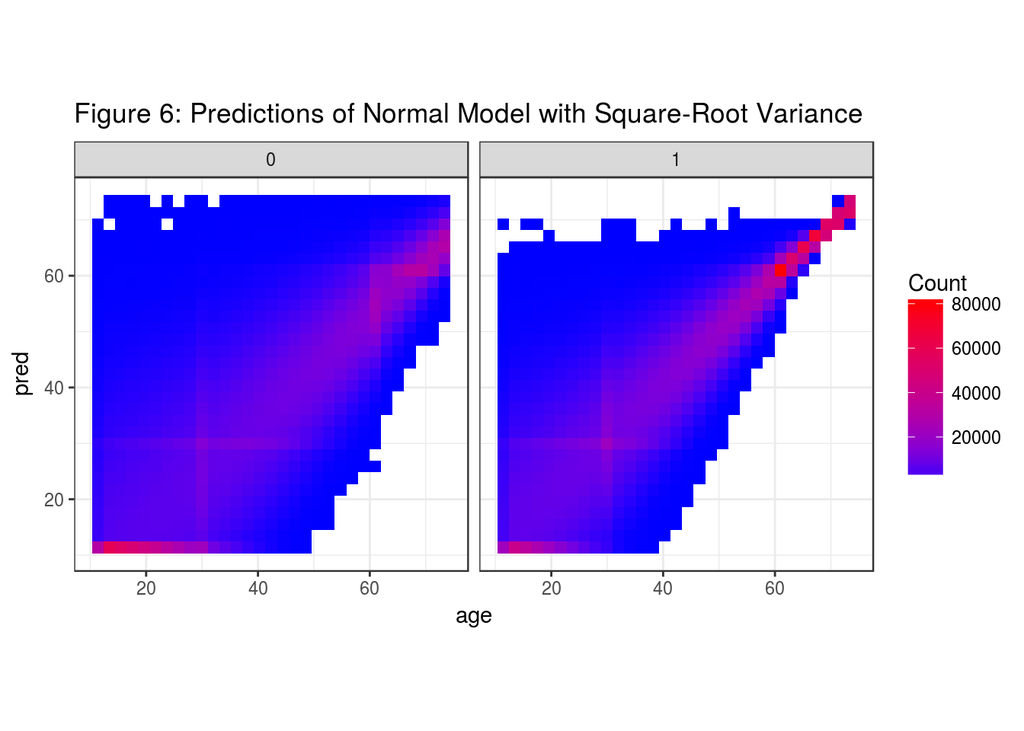

```r
plot_preds(norm_sqrt_preds, "Figure 6: Predictions of Normal Model with Square-Root Variance")
```

# Deviance Information Criterion

To compare the four models presented, we used the deviance information criterion (DIC), which is an estimate of the expected predicted *deviance* (Gelman 2004). The deviance is defined as

$$D(y, \theta) = -2 \log{p(y | \theta)}$$

where $p(y | \theta)$ is the likelihood – i.e., the probability of observing the data under the parameter vector $\theta$. Then, the expected predicted deviance is a measure of the prediction error - the error we could expect on new data - and lower DIC corresponds to a better model (loosely speaking). In R, we can measure the DIC of a Bayesian model using `dic.samples()` in `rjags`.

# Results

## Model Comparisons

The model DICs are shown below:

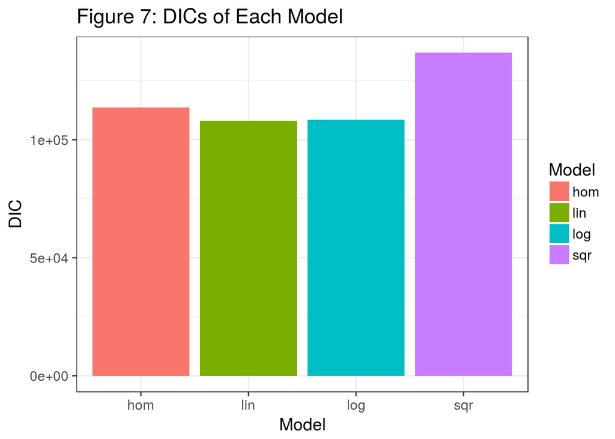

```r
dics <- data.frame(
    "Model" = c("hom", "lin", "log", "sqr"),
    "DIC" = c(sum(norm_hom_preds$dic), sum(norm_lin_preds$dic), sum(norm_log_preds$dic),
              sum(norm_sqrt_preds$dic))
)

ggplot(dics) +
  geom_bar(aes(x = Model, y = DIC, fill = Model), stat = "identity") +
  ggtitle("Figure 7: DICs of Each Model") +
  theme_bw(base_size = 14)
```

The linear heteroscedastic model has a noticeable edge over the homoscedastic model, and performed the best out of all the models. Of the heteroscedastic models, the square-root variance model performed the worst.

## Coefficient Estimates

We infer coefficient values from the samples from the approximated posterior distributions. Two questions are of particular interest:

1. Is there a gender effect? That is, is $\beta_2$, the coefficient for $G_i$, nonzero? What is the magnitude and direction of $\beta_2$, and how does it vary across models?
2. Is there evidence of heteroscedasticity in the models? What are the values of $\alpha_1$ (which would indicate heteroscedasticity with respect to age) and $\alpha_2$ (which regards heteroscedasticity with respect to gender)?

We answer these questions in Figure 8.

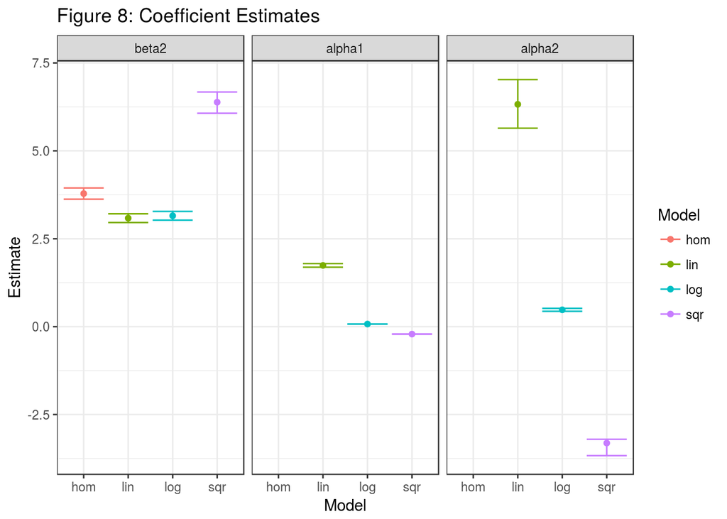

As we can see, the coefficent for the effect of gender varies from model to model, but it is almost certain that females of a given age choose older partners than males of the same age, as all the gender effect coefficients are positive. The square-root model estimate seems to be an outlier. Also, the square-root model predicts a decrease in variance by age, which contradicts the other two models. In all 3 heteroscedastic models, the probability that the coefficient is nonzero is essentially 1, so the models support the conclusion of the BP test, which was that there was heteroscedasticity present in the data.

# Conclusions and Future Research

Of the four models compared here, the linear variance model performed the best. Its simpler form and seemingly more accurate results make it a better option than the other heteroscedastic models. In the end, the application will dictate whether a heteroscedastic model is needed. In this case, a heteroscedastic model adds substantial information to the results, which can be seen by comparing the plot of the constant variance predictions (Figure 3) and the plot of the linear variance (Figure 4).

Next steps could involve modeling the error distributions as non-normal. This would result in non-normal age distributions for each age. Of particular interest is the Laplace distribution, which has a sharply pointed mean/mode/median and fatter tails than the Normal distribution. In addition, verification of the square root results and theories about the failure of the square root regression model would be of interest. There are also other sexual behavior surveys, such as the [National Survey on Family Growth](https://www.cdc.gov/nchs/nsfg/). Future analysis could compare the sexual behavior of British and US adults, and the variance structure within each.

# Appendices

## JAGS Output

In the following, I plot the trace and density plots for the 4 models.

### Normal, Homoscedastic

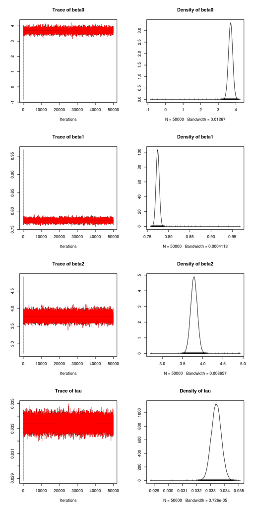

```r
plot(norm_hom_preds$jags_obj)
```

### Normal, Linear Variance

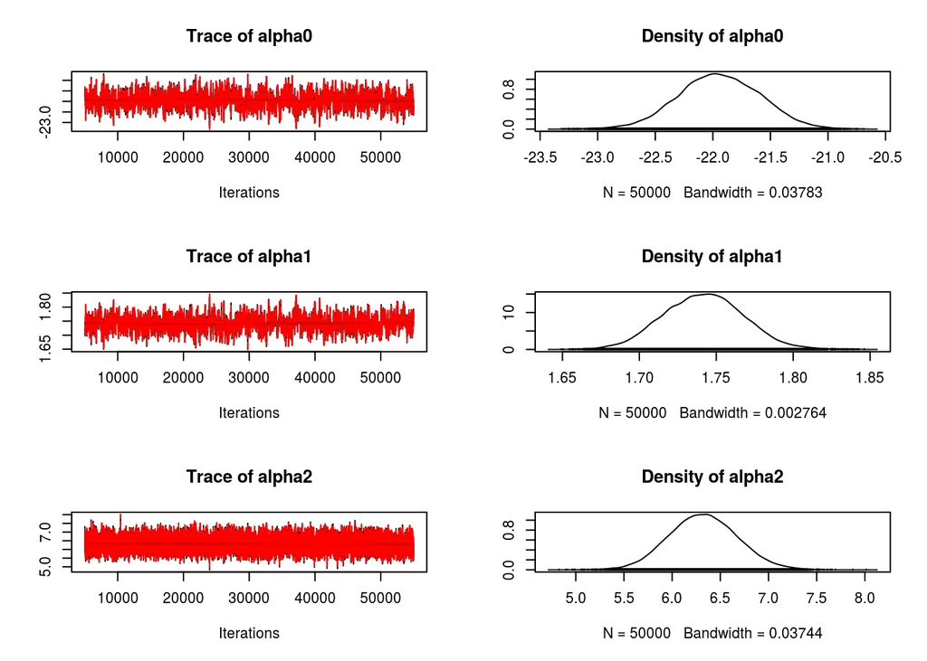

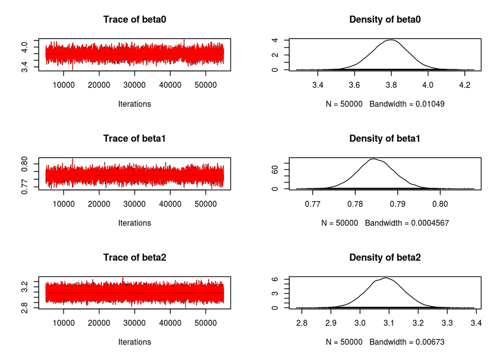

```r
plot(norm_lin_preds$jags_obj)
```

### Normal, Log-linear Variance

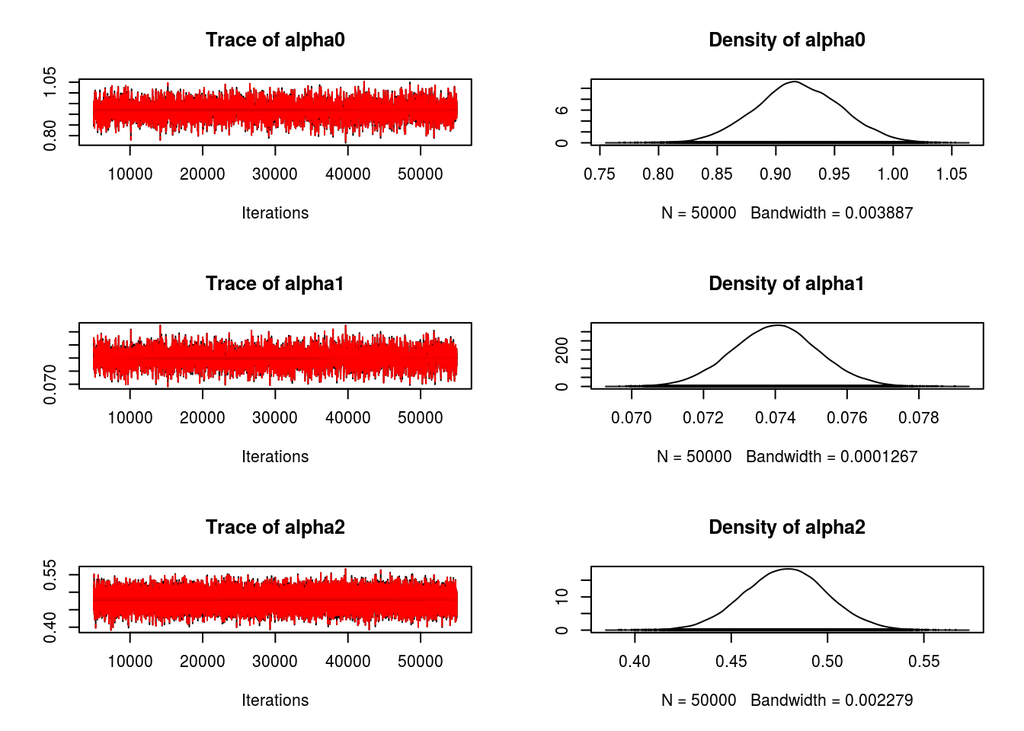

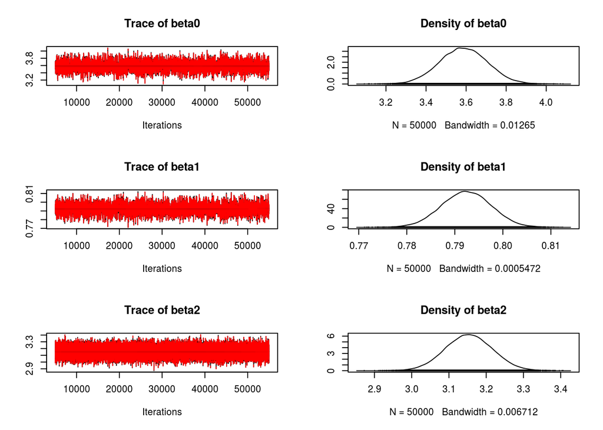

```r
plot(norm_log_preds$jags_obj)
```

### Normal, Square-root Variance

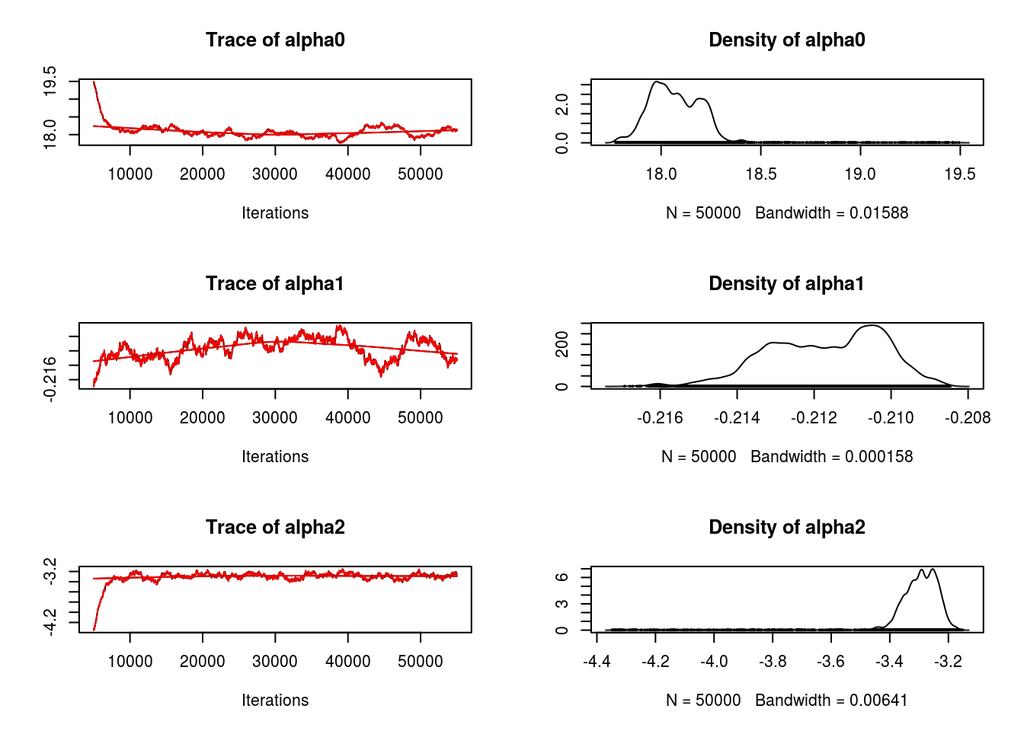

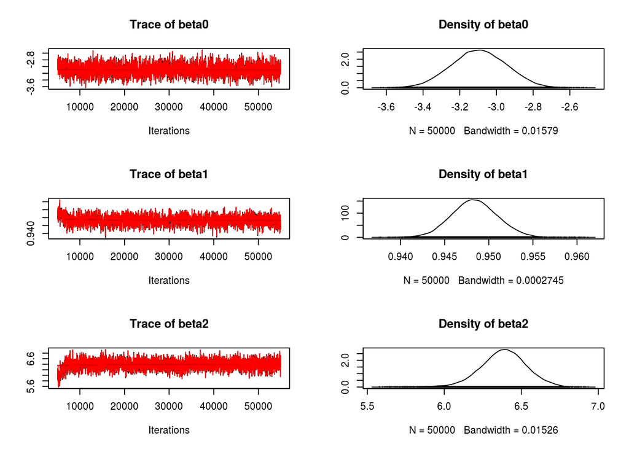

```r
plot(norm_sqrt_preds$jags_obj)
```

## Code Appendix

```r
cat(htmltools::includeText("het_analysis.R"))
```

```
# used to restrict predicted ages to the population ages of 12 to 74
# in addition, takes the floor of the predicted ages
restrict_pred_ages <- function(pred_age_df){
  pred_age_df$pred[which(pred_age_df$pred < 12)] <- 12
  pred_age_df$pred[which(pred_age_df$pred > 74)] <- 74
  pred_age_df$pred <- floor(pred_age_df$pred)
  pred_age_df
}


# function to carry out jags analysis
het_analysis <- function(nreps, jags_model_text,
                         distribution = c("norm", "lap"),
                         variance_model = c("hom", "lin", "loglin", "sqrt"),
                         spc_df, jags.plot = FALSE, jags.quiet = TRUE){

  # match distributions
  distr <- match.arg(distribution)
  if (distr == "norm"){
    dist_ind <- 0
  } else {
    dist_ind <- 1
  }

  # match variance model
  var_mod <- match.arg(variance_model)
  if (variance_model == "lin"){
    var_ind <- 0
  } else if (variance_model == "loglin"){
    var_ind <- 1
  } else {
    var_ind <- 2
  }

  # construct the jags model
  age_jags_model_object <- jags.model(textConnection(jags_model_text),
                                      n.chains = 2, # need two chains for dic
                                      data = list(y = spc_df$ptage,
                                                  x = spc_df$chsage,
                                                  sex = spc_df$sex_dummy),
```

[output cut: 77 more lines]

```

    # restrict predicted ages to between 12 and 74 and take the floor of predicted age
    het_df_rest <- restrict_pred_ages(het_predictions_df)

    # take samples to calculate the dic
    dic <- dic.samples(age_jags_model_object, n.iter = nreps)

    return(list(
      "predictions" = het_df_rest,
      "dic" = dic$deviance, # extract the deviance values
      "jags_samps" = jags_samples_df,
      "jags_obj" = jags_samples
    ))
  }
}
```

```r
cat(htmltools::includeText("resid_model_prediction.cpp"))
```

```
#include <Rcpp.h>
#include <math.h> // for exp

using namespace Rcpp;

// [[Rcpp::export]]
double rlaplace_rcpp(double loc, double jags_scale){
  // use the fact that a Laplace(loc, jags_scale) distribution is the shifted difference of
  // two i.i.d. Expo(scale) distributions (when expo is parameterized by scale, as it is here)
  double exp1 = R::rexp(1/jags_scale);
  double exp2 = R::rexp(1/jags_scale);
  double rlap = loc + (exp1 - exp2);
  return rlap;
}


// [[Rcpp::export]]
List resid_model_prediction(NumericVector beta0,
                            NumericVector beta1,
                            NumericVector beta2,
                            NumericVector alpha0,
                            NumericVector alpha1,
                            NumericVector alpha2,
                            NumericVector ages,
                            int distribution,
                            int variance_model) {

  // if distribution == 0, normal
  // else laplace

  // if variance_model == 0, linear
  // if variance_model == 1, log-linear
  // if variance_model == 2, sqrt
  // if variance_model == 3, homosced.

  int n_samps = beta0.size();
  int n_age = ages.size();
  int n_gender = 2;

  int n_total = n_samps * n_age * n_gender;
```

[output cut: 64 more lines]

```
        sigma[i] = var_temp;
        pred_age[accu] = rlaplace_rcpp(mu[i], sigma[i]);
      }

      // record age and sex
      var_age[accu] = age_vector[j];
      var_sex[accu] = sex_vector[j];

      accu += 1;
    }
  }
  // NumericVector pred = rnorm(10, mu, sd);

  return Rcpp::List::create(pred_age, var_sex, var_age, mu, sigma);
}
```

# Bibliography

Breusch, T. S., and A. R. Pagan. 1979. “A Simple Test for Heteroscedasticity and Random Coefficient Variation.” *Econometrica* 47 (5). [Wiley, Econometric Society]: 1287–94. http://www.jstor.org/stable/1911963.

Easterly, C. W. 2017. “Mathematical Models of Human Papillomavirus: Questioning Assumptions About Sexual Behavior.” *Mathematics, Statistics, and Computer Science Honors Projects*. Macalester College.

Garnett, G. P. 2002. “An Introduction to Mathematical Models in Sexually Transmitted Disease Epidemiology.” *Sexually Transmitted Infections* 78 (1): 7–12. doi:10.1136/sti.78.1.7.

Gelman, Andrew, ed. 2004. *Bayesian Data Analysis*. 2nd ed. Texts in Statistical Science. Boca Raton, Fla: Chapman & Hall/CRC.

Johnson, A. 2015. “National Survey of Sexual Attitudes and Lifestyles, 2010-2012.” Colchester, Essex: UK Data Archive. https://doi.org/10.5255/UKDA-SN-7799-1.